# 03 Automated Machine Learning with H20

2024-07-06

# 1 Challenges Chapter 1

Last compiled: 2024-06-26

1.Compensation Features

What can you deduce about the interaction between Monthly Income and Attrition?

3. Those that are leaving have a lower Monthly Income

2.Compensation Features

What can you deduce about the interaction between Percent Salary Hike and Attrition?

4. It’s difficult to deduce anything based on the visualization

3.Compensation Features

What can you deduce about the interaction between Stock Option Level and Attrition?

3. It’s difficult to deduce anything based on the visualization

4.Survey Results

What can you deduce about the interaction between Environment Satisfaction and Attrition?

1. A higher proportion of those leaving have a low environment satisfaction level

5.Survey Results

What can you deduce about the interaction between Work Life Balance and Attrition

2. Those that are staying have a higher density of 2’s and 3’s

6.Performance Data

What Can you deduce about the interaction between Job Involvement and Attrition?

1. Those that are leaving have a lower density of 3’s and 4’s

7.Work-Life Features

What can you deduce about the interaction between Over Time and Attrition?

8.Training and Education

What can you deduce about the interaction between Training Times Last Year and Attrition

9.Time-Based Features

What can you deduce about the interaction between Years At Company and Attrition

2. People that leave tend to have less working years at the company

10.Time-Based Features

What can you deduce about the interaction between Years Since Last Promotion and Attrition?

3. It’s difficult to deduce anything based on the visualization

## 1.1 Code

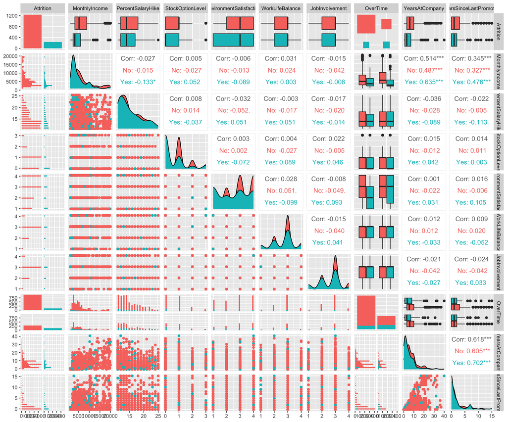

```r
library(h2o)
library(tidyverse)
source('extract_h2o_model_name_by_position.R')
library(readxl)
library(skimr)
library(GGally)
employee_attrition_tbl <- read_csv("datasets-1067-1925-WA_Fn-UseC_-HR-Employee-Attrition.csv")



# Select relevant columns
selected_columns <- employee_attrition_tbl %>%
  select(Attrition, contains("MonthlyIncome"), contains("Hike"), contains("Stock"),
         contains("Environment"), contains("WorkLifeBalance"), contains("JobInvolvement"),
         contains("OverTime"), contains("TrainingTimeLastYear"), contains("YearsAtCompany"),
         contains("YearsSinceLast"))

# Create a pair plot
ggpairs(selected_columns, aes(color = Attrition))
```

# 2 Challenges Chapter 2

## 2.1 Code

```r
# Load data
library(tidyverse)
source('extract_h2o_model_name_by_position.R')
library(readxl)
library(rsample)
library(recipes)
library(PerformanceAnalytics)

#0.Fetching Data and Reducing as required
product_backorders_raw <- read_csv("product_backorders.csv")

product_backorders_tbl <- product_backorders_raw %>%
  select(sku,national_inv,forecast_9_month,sales_9_month,went_on_backorder)

#1.Load the training & test dataset
set.seed(seed = 1122)
split_obj                       <- rsample::initial_split(product_backorders_tbl, prop = 0.85)
train_backorder_tbl              <- training(split_obj)
test_backorder_tbl               <- testing(split_obj)

recipe_obj <- recipe(went_on_backorder ~., data = train_backorder_tbl) %>%
  step_zv(all_predictors()) %>%
  prep()

train_tbl <- bake(recipe_obj, new_data = train_backorder_tbl)
test_tbl  <- bake(recipe_obj, new_data = test_backorder_tbl)




h2o.init()
split_h2o <- h2o.splitFrame(as.h2o(train_tbl), ratios = c(0.85), seed = 1122)
train_h2o <- split_h2o[[1]]
valid_h2o <- split_h2o[[2]]
test_h2o  <- as.h2o(test_tbl)


write_rds(valid_h2o, "valid_h2o.rds")
write_rds(train_h2o, "train_h2o.rds")


valid_h2o<-read_rds("valid_h2o.rds")
train_h2o<-read_rds("train_h2o.rds")


#2.Specifiy the response and predictor variables
y <- "went_on_backorder"
x <- setdiff(names(train_h2o), y)



#3.Run AutoML specifying the stopping criterion
automl_models_h2o <- h2o.automl(
  x = x,
  y = y,
  training_frame    = train_h2o,
  validation_frame  = valid_h2o,
  leaderboard_frame = test_h2o,
  max_runtime_secs  = 30,
  nfolds            = 5
)
```

```r
#4.View the leaderboard
automl_models_h2o@leaderboard
```

```
##                                                   model_id       auc   logloss
## 1    StackedEnsemble_AllModels_1_AutoML_20_20240626_131929 0.9291155 0.1985924
## 2 StackedEnsemble_BestOfFamily_2_AutoML_20_20240626_131929 0.9289851 0.1978134
## 3 StackedEnsemble_BestOfFamily_1_AutoML_20_20240626_131929 0.9285673 0.1983470
## 4                      XGBoost_1_AutoML_20_20240626_131929 0.9281672 0.2033788
## 5                          GBM_1_AutoML_20_20240626_131929 0.9258195 0.2007038
## 6                      XGBoost_2_AutoML_20_20240626_131929 0.9254973 0.2064081
##       aucpr mean_per_class_error      rmse        mse
## 1 0.6530793            0.1395470 0.2434317 0.05925898
## 2 0.6555752            0.1492733 0.2427779 0.05894109
## 3 0.6512164            0.1479835 0.2429344 0.05901713
## 4 0.6446364            0.1482797 0.2454427 0.06024210
## 5 0.6521362            0.1512559 0.2439927 0.05953242
## 6 0.6329995            0.1825129 0.2481771 0.06159186
##
## [11 rows x 7 columns]
```

```r
h2o_model<-automl_models_h2o@leaderboard %>%
  extract_h2o_model_name_by_position(1) %>%
  h2o.getModel()
#5.Predicting using Leader Model
predictions <- h2o.predict(h2o_model, newdata = as.h2o(test_tbl))
```

```r
predictions %>% as_tibble()
```

| predict | No | Yes |
| --- | --- | --- |
| Yes | 0.13359048 | 0.866409519 |
| Yes | 0.24259791 | 0.757402091 |
| Yes | 0.52308463 | 0.476915375 |
| Yes | 0.20992692 | 0.790073076 |
| Yes | 0.17638552 | 0.823614478 |
| No | 0.69455575 | 0.305444251 |
| No | 0.74526615 | 0.254733847 |
| Yes | 0.65079238 | 0.349207618 |
| Yes | 0.24645479 | 0.753545211 |
| Yes | 0.36643407 | 0.633565932 |

[output cut: 2848 more lines]

```r
#6.Save the leader model
h2o_model%>%h2o.saveModel(path = "h20_models/") %>% invisible()
```